# Proyecto Estadística

## Ganancia anual para los trabajadores asalariados según tengan o no discapacidad, enfocado en sexo y tipo de discapacidad

Durante este proyecto de estadística, encontramos un archivo CSV con información detallada sobre los salarios de personas con discapacidad. Este conjunto de datos incluye variables como género, tipo de discapacidad (física o sensorial), y evolución de los salarios a lo largo del tiempo. Nuestro objetivo principal será analizar estos datos para responder preguntas clave relacionadas con las diferencias salariales y su evolución en función de diversos factores.

Este análisis nos permitirá identificar patrones, desigualdades y posibles tendencias en los salarios de personas con discapacidad, contribuyendo a una mejor comprensión de la situación actual y proporcionando información útil para futuras iniciativas de inclusión laboral.

## Preguntas a responder

- ¿Existe una diferencial salarial más pronunciada entre hombres y mujeres en función de una misma discapacidad?
- ¿Existe una diferencia salarial dependiendo de discapacidades distintas (físicas vs sensoriales)?
- ¿A lo largo de los años, han aumentado los salarios de los discapacitados (tanto físicas como sensoriales)?

## Código

```r
library(readr)
library(dplyr)
```

```r
library(ggplot2)
library(lubridate)
library(tidyverse)
# Lectura del archivo csv
datos <- read_delim("8534.csv",
    delim = ";", escape_double = FALSE, trim_ws = TRUE)
# Filtrado de datos
datos = filter(datos, Sexo != "Ambos sexos")
datos = filter(datos, `Tipo de indicador` != "Ganancia (bruta) por hora y año")
datos = filter(datos, `Tipo de discapacidad` != "No consta")
datos = filter(datos, `Tipo de discapacidad` != "Mental")
datos = filter(datos, `Tipo de discapacidad` != "Total")
datos = filter(datos, `Total` > 0)

print(datos)
```

```
## # A tibble: 48 × 6
##    Sexo  `Tipo de discapacidad` `Tipo de indicador` Personas con discapa…¹   año
##    <chr> <chr>                  <chr>               <chr>                  <dbl>
##  1 Homb… Física y otras         Ganancia (bruta) p… Personas con discapac…  2022
##  2 Homb… Física y otras         Ganancia (bruta) p… Personas con discapac…  2021
##  3 Homb… Física y otras         Ganancia (bruta) p… Personas con discapac…  2020
##  4 Homb… Física y otras         Ganancia (bruta) p… Personas con discapac…  2019
##  5 Homb… Física y otras         Ganancia (bruta) p… Personas con discapac…  2018
##  6 Homb… Física y otras         Ganancia (bruta) p… Personas con discapac…  2017
##  7 Homb… Física y otras         Ganancia (bruta) p… Personas con discapac…  2016
##  8 Homb… Física y otras         Ganancia (bruta) p… Personas con discapac…  2015
##  9 Homb… Física y otras         Ganancia (bruta) p… Personas con discapac…  2014
## 10 Homb… Física y otras         Ganancia (bruta) p… Personas con discapac…  2013
## # ℹ 38 more rows
## # ℹ abbreviated name: ¹`Personas con discapacidad`
## # ℹ 1 more variable: Total <dbl>
```

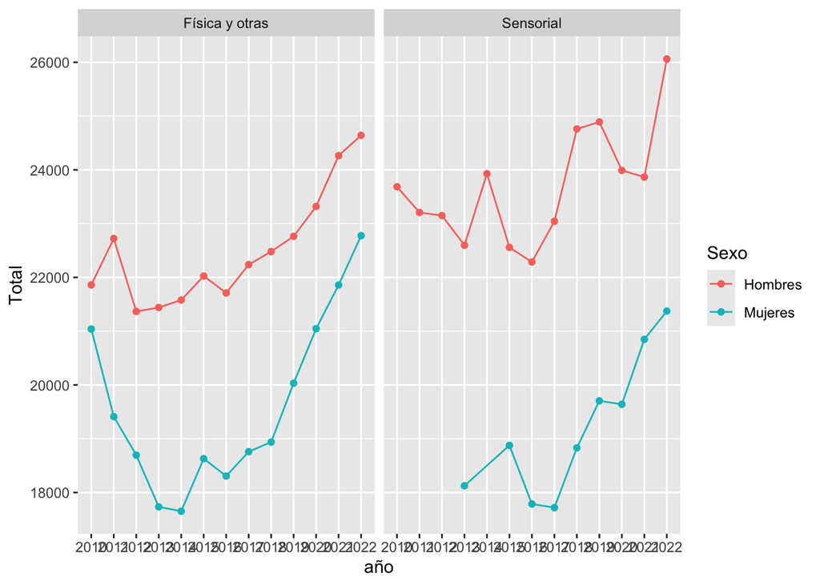

```r
# Convertir la columna sexo y año en un factor
datos$Sexo = factor(datos$Sexo)
datos$año = factor(datos$año, ordered = TRUE)

# Creación de gráfico
ggplot(datos, aes(x = año, y = Total, col=Sexo)) + geom_point() + geom_line(aes(group=Sexo)) + facet_wrap(~ `Tipo de discapacidad`)
```

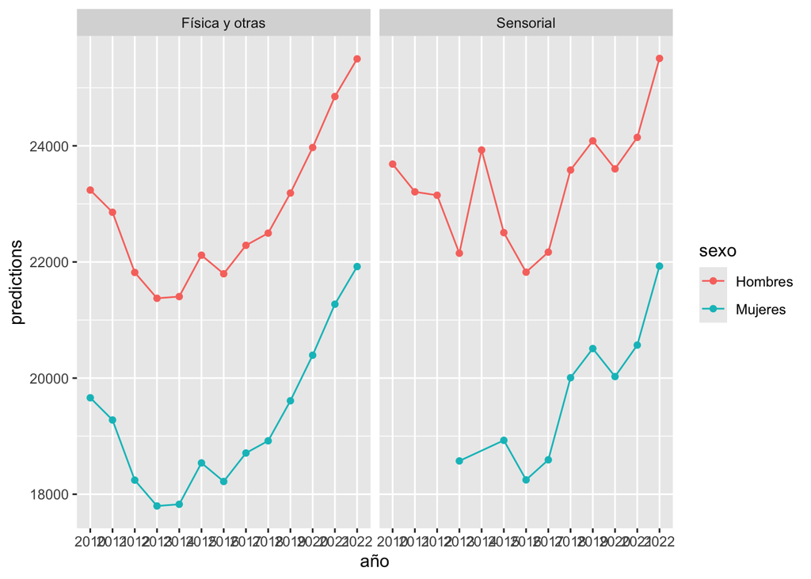

```r
# Creación de un nuevo dataframe
df = data.frame(
  'total' = datos$Total,
  'sexo' = datos$Sexo,
  'año' = datos$año,
  'discapacidad' = datos$`Tipo de discapacidad`
)

# Convertir la columna año en un factor ordenado
df$año = factor(df$año, ordered = TRUE)

# Modelo de regresión lineal
model = lm(total ~ sexo + año * discapacidad, df)

# Predicciones del modelo
df$predictions = predict(model)

# Gráfico de comparación entre las predicciones
ggplot(df, aes(x = año, y = predictions, col=sexo)) + geom_point() + geom_line(aes(group=sexo)) + facet_wrap(~ discapacidad)
```

```r
# Resumen del modelo ajustado
summary(model)
```

```
##
## Call:
## lm(formula = total ~ sexo + año * discapacidad, data = df)
##
## Residuals:
##     Min      1Q  Median      3Q     Max
## -1378.2  -395.9     0.0   395.9  1378.2
##
## Coefficients:
##                              Estimate Std. Error t value Pr(>|t|)
## (Intercept)                  22837.93     210.50 108.494  < 2e-16 ***
## sexoMujeres                  -3577.01     256.58 -13.941 4.38e-12 ***
## año.L                         2959.42     601.73   4.918 7.27e-05 ***
## año.Q                         3225.67     601.73   5.361 2.57e-05 ***
## año.C                         -454.93     601.73  -0.756   0.4580
## año^4                          113.64     601.73   0.189   0.8520
## año^5                          -38.92     601.73  -0.065   0.9490
## año^6                         -530.29     601.73  -0.881   0.3881
## año^7                          338.05     601.73   0.562   0.5802
## año^8                          -31.16     601.73  -0.052   0.9592
## año^9                         -129.28     601.73  -0.215   0.8320
## año^10                          73.88     601.73   0.123   0.9034
## año^11                         103.47     601.73   0.172   0.8651
## año^12                        -365.65     601.73  -0.608   0.5499
## discapacidadSensorial          511.52     256.58   1.994   0.0593 .
## año.L:discapacidadSensorial  -1313.12     954.69  -1.375   0.1835
## año.Q:discapacidadSensorial   -901.64     926.02  -0.974   0.3413
## año.C:discapacidadSensorial    687.79     924.48   0.744   0.4651
## año^4:discapacidadSensorial   -210.75     921.83  -0.229   0.8214
## año^5:discapacidadSensorial    122.18     935.27   0.131   0.8973
## año^6:discapacidadSensorial   1526.41     909.68   1.678   0.1082
## año^7:discapacidadSensorial    301.90     918.91   0.329   0.7458
## año^8:discapacidadSensorial   -890.28     936.90  -0.950   0.3528
## año^9:discapacidadSensorial   -659.36     892.69  -0.739   0.4683
## año^10:discapacidadSensorial   764.03     893.49   0.855   0.4021
## año^11:discapacidadSensorial  -724.65     905.46  -0.800   0.4325
## año^12:discapacidadSensorial   788.82     871.44   0.905   0.3756
## ---
## Signif. codes:  0 '***' 0.001 '**' 0.01 '*' 0.05 '.' 0.1 ' ' 1
##
## Residual standard error: 851 on 21 degrees of freedom
## Multiple R-squared:  0.9368, Adjusted R-squared:  0.8586
## F-statistic: 11.98 on 26 and 21 DF,  p-value: 1.177e-07
```

## Limitaciones encontradas

- Se realizó un filtrado de datos del archivo 8534.csv en las categorías sexo, tipo de indicador, tipo de discapacidad y total, debido a que, estas contaban con datos negativos, no significativos para la práctica o datos insuficientes para llevar a cabo el análisis.
- Se realizó una conversión a un factor para las categorías de sexo y año, con la finalidad de manejar datos categóricos de manera eficiente, ya que, estos mostraban decimales en el gráfico.
- Al momento de realizar el modelo lineal, nos pudimos percatar de que el p-valor de la discapacidad sensorial se encontraba en el rango límite, por lo cual, no podiamos concluir que nuestra evidencia fuera significativa, es por esto, por lo que la hemos establecido como débil.

## Conclusiones

Los datos aportan suficiente evidencia de que el sexo afecta de manera significativa las ganancias salariales. A través de nuestro análisis pudimos percatarnos de que existe una brecha salarial notable entre hombres y mujeres con la misma discapacidad, mediante el cual se demuestra que las personas de sexo femenino ganan una media de 3577.01 euros menos que las personas de sexo masculino (p-valor: 4.38e-12, IC: -4110.59542 -3043.4319).

Hemos encontrado evidencia débil de que existe una diferencia salarial dependiendo de la discapacidad de las personas, en este caso se realizó la comparación de las discapacidades fisicas contra las sensoriales. Después de realizar el análisis se obtuvo que las personas con discapacidades sensoriales cuentan con una ganancia media de 511.52 más que las personas con discapacidades físicas (p-valor: 0.0593, IC: -22.06465 1045.0989).

Asimismo, mediante las gráficas se demuestra que de los años 2010-2022 las ganancias salariales de los hombres con discapacidad sensorial se encontraron por encima de los 22 mil euros anuales, en comparación de los que contaban con discapacidades físicas, los cuales comenzaron a aumentar sus ganancias a partir del año 2014. De igual forma, entre los años 2013-2022, las mujeres con discapacidad sensorial obtuvieron una ganancia media de más de 18 mil euros anuales, durante este tiempo también se observaron altibajos en el salario obtenido. En cambio, en las mujeres con discapacidad física se observa un descenso significativo en su salario durante los años 2010-2014, debido a la crisis economica del 2008, después de estos años sus ganancias anuales fueron ascendiendo hasta llegar a los 22 mil euros al año.

Debido a que el intervalo de confianza obtenido para los coeficientes de los años es positivo tanto para el componente lineal (ICL: [1708.06, 4210.78]) como para el componente cuadrático (ICQ: [1974.31, 4477.03]), se concluye que existe una tendencia general con curvatura convexa en la relación entre los años y las ganancias. Esto sugiere que, que a partir del año 2014 el salario aumenta a medida que el tiempo aumenta.